IAM chain v4 · run RUN-20261025-01 · 2026-10-25 16:58 UTC

# Sample report: ROUTE

The information physics of methylation, read on one sample

Specimen cell line · platform sequencing values (development)

**Research use only. Not a diagnostic test.** Each reading is printed with its commissioning status: *commissioned* means it passed a test sealed before its data was seen; a reading outside what an instrument was tested on is still shown, and says so.

## At a glance

| Instrument | Question it answers | Reading | State | Status |
| --- | --- | --- | --- | --- |
| **IAM-Deconvolver** | Which cells, in what shares | Naive b cells 56.4 %, Lung interstitial macrophages 35.6 %, T effector memory cd4 3.5 % |  | This share is preliminary until the IAM-Deconvolver is officially commissioned on a panel of 79 cell types. |
| **Met-A** | How far the neutrophil's tagging level has moved |  |  | not run (no array input) |
| **Met-A, each cell** | How far each blood cell's tagging level has moved (against IAM-Atlas v2.1 in this person's own cell mix) |  |  | This score is preliminary until Met-A is officially commissioned on each blood cell in whole blood. |
| **Met-A, whole sample** | Has the sample as a whole departed from its own expected healthy self, over every atlas site | A 0.78996 (55,480 sites; identity sites of the cells found 0.64928; islands 0.22113; domains 0.93428; the rest 0.80709) |  | development, not commissioned; untared |
| **Territories** | Gains at islands every healthy cell keeps unmarked; losses in loosely held domains | islands A 0.21798, level change -0.03492; domains A 0.90742, level change +0.00482 |  | development, not commissioned; untared |
| **Information sphere** | Which cell programs moved, and how far the sample sits from its own expected healthy self | 2 of 11 territories changed; distance 0.26559 rad |  | development, not commissioned (page methylphys_report_info_sphere.html) |
| **C-Score, commissioned** | Are the neutrophil's departures clustered or scattered |  |  | not run |
| **C-Score, whole genome** | Are the departures clustered, over every atlas site | C 1.0173 |  | development, not commissioned |
| **C-Score, each cell** | Are each cell's departures clustered | Naive b cells 0.882, Lung interstitial macrophages 1.190, T effector memory cd4 1.021, Fallopien tubes epithelium 0.852, NK cells 1.050, Erythrocyte progenitors 0.817 |  | development, not commissioned |
| **C-Score, IAM-A** | Are the held-error departures clustered, region by region |  |  | not run (needs sequencing input) |
| **Globe** | Where on the genome the sample changed | 5 of 5,548 blocks changed |  | development, not commissioned |
| **Group-A** | Does this person's group differ from its healthy group |  |  | a group reading: shown in the series summary when this sample is read as one member of a series |
| **IAM-A** | Is each mark still held, against the sample's own reference | A 0.8633 | Normal | This score is preliminary until IAM-A is officially commissioned on mixed specimen (cell line). |

## How to read this report

A methyl mark on DNA is a stored record. A cell writes it and then has to keep it against the constant agitation of heat, and keeping a record costs energy. Landauer's principle sets the least energy needed to hold one bit against heat; IAM's Law is that the same cost governs every physical record, from a qubit or a transistor to a methyl mark. For a cell this gives a scale that is not fitted to any group of people: a floor, where heat alone would set the error, and saturation, where a site has lost its mark entirely and reads as a coin flip. A healthy cell sits at a measured place between the two.

Every reading in this report is a ratio to its healthy expectation, so healthy reads 1. Readings are disorder in bits (Shannon entropy of the methylation level at each site), never a difference from a control group's average. Above 1 means more disorder than the healthy expectation: marks are being lost or gained where the healthy cell holds them. Below 1 means more order than expected.

The healthy expectation is built from this sample itself wherever possible: IAM-Atlas v2.1, 79 purified healthy human cell types, mixed in the shares the IAM-Deconvolver finds in this sample. No other person's sample is needed for the atlas readings, and IAM-A on sequencing needs none at all: its healthy mark is computed from the sample's own molecules.

The genome is read with the statistical methods cosmology built to map the microwave sky. Cosmologists read a faint signal spread over millions of positions, through instruments that each carry their own offset, and still state how sure they are at every point. The atlas was fitted the way a sky map is made (every source at once, each source's offset fitted beside the biology, an uncertainty at every value). Every site is placed on a HEALPix sphere, the equal-area pixelization of the Planck and WMAP maps, so clustered change shows as patches and scattered noise as speckle, and the sky's own measures (masks, power spectra, clustering) apply unchanged.

Status. Each reading carries its status. Commissioned means the instrument passed a test written and sealed before its data was seen, in the scope it was tested on. Development means the reading is produced by the same chain and shown so it can be examined, but it has not yet passed its own sealed test; it is flagged and is not to be used as a finding. This report is for research use only.

## The physics behind each reading

One law runs under every reading here: a mark held against thermal noise costs energy, and the loss of that hold shows as entropy, in bits. Each reading is a ratio to its healthy reference, so healthy reads 1. Its gauge runs from 0, the floor (below it a cell can no longer hold its identity), to saturation, the most the scale can register (every identity site fully scrambled). Both ends are derived from physics, not fitted to data.

[output not shown]

## Cell shares: IAM-Deconvolver against IAM-Atlas v2.1

| Cell |  | Share | Range (information) | Status |
| --- | --- | --- | --- | --- |
| Naive b cells |  | **56.4 %** | 10.4 to 60.0 % | This share is preliminary until the IAM-Deconvolver is officially commissioned on naive b cells. |
| Lung interstitial macrophages |  | **35.6 %** | 0.5 to 36.7 % | This share is preliminary until the IAM-Deconvolver is officially commissioned on lung interstitial macrophages. |
| T effector memory cd4 |  | **3.5 %** | 0.0 to 10.6 % | This share is preliminary until the IAM-Deconvolver is officially commissioned on t effector memory cd4. |
| Fallopien tubes epithelium |  | **1.9 %** | 0.0 to 5.0 % | This share is preliminary until the IAM-Deconvolver is officially commissioned on fallopien tubes epithelium. |
| NK cells |  | **0.8 %** | 0.0 to 19.8 % | This share is preliminary until the IAM-Deconvolver is officially commissioned on NK cells. |
| Erythrocyte progenitors |  | **0.8 %** | 0.0 to 9.3 % | This share is preliminary until the IAM-Deconvolver is officially commissioned on erythrocyte progenitors. |
| Colon macrophages |  | **0.6 %** | 0.0 to 19.4 % | This share is preliminary until the IAM-Deconvolver is officially commissioned on colon macrophages. |
| Lung alveolar macrophages |  | **0.5 %** | 0.0 to 24.2 % | This share is preliminary until the IAM-Deconvolver is officially commissioned on lung alveolar macrophages. |
| CMP (bone marrow) |  | **0.0 %** | 0.0 to 2.9 % | This share is preliminary until the IAM-Deconvolver is officially commissioned on CMP (bone marrow). |
| GMP (bone marrow) |  | **0.0 %** | 0.0 to 18.4 % | This share is preliminary until the IAM-Deconvolver is officially commissioned on GMP (bone marrow). |
| HSC (bone marrow) |  | **0.0 %** | 0.0 to 0.0 % | This share is preliminary until the IAM-Deconvolver is officially commissioned on HSC (bone marrow). |
| L-MPP (bone marrow) |  | **0.0 %** | 0.0 to 11.0 % | This share is preliminary until the IAM-Deconvolver is officially commissioned on L-MPP (bone marrow). |
| MEP (bone marrow) |  | **0.0 %** | 0.0 to 5.8 % | This share is preliminary until the IAM-Deconvolver is officially commissioned on MEP (bone marrow). |
| MPP (bone marrow) |  | **0.0 %** | 0.0 to 8.2 % | This share is preliminary until the IAM-Deconvolver is officially commissioned on MPP (bone marrow). |
| Adipocytes |  | **0.0 %** | 0.0 to 0.0 % | This share is preliminary until the IAM-Deconvolver is officially commissioned on adipocytes. |
| Aorta endothelium |  | **0.0 %** | 0.0 to 0.0 % | This share is preliminary until the IAM-Deconvolver is officially commissioned on aorta endothelium. |
| Astrocytes |  | **0.0 %** | 0.0 to 3.6 % | This share is preliminary until the IAM-Deconvolver is officially commissioned on astrocytes. |
| B cells |  | **0.0 %** | 0.0 to 37.6 % | This share is preliminary until the IAM-Deconvolver is officially commissioned on B cells. |
| Basophils |  | **0.0 %** | 0.0 to 0.0 % | This share is preliminary until the IAM-Deconvolver is officially commissioned on basophils. |
| Bladder epithelium |  | **0.0 %** | 0.0 to 0.0 % | This share is preliminary until the IAM-Deconvolver is officially commissioned on bladder epithelium. |
| Breast basal epithelium |  | **0.0 %** | 0.0 to 1.8 % | This share is preliminary until the IAM-Deconvolver is officially commissioned on breast basal epithelium. |
| Breast luminal epithelium |  | **0.0 %** | 0.0 to 0.0 % | This share is preliminary until the IAM-Deconvolver is officially commissioned on breast luminal epithelium. |
| Cardiomyocyte |  | **0.0 %** | 0.0 to 0.2 % | This share is preliminary until the IAM-Deconvolver is officially commissioned on cardiomyocyte. |
| CD4 T cells |  | **0.0 %** | 0.0 to 0.0 % | This share is preliminary until the IAM-Deconvolver is officially commissioned on CD4 T cells. |
| Cd56bright nk cells |  | **0.0 %** | 0.0 to 2.3 % | This share is preliminary until the IAM-Deconvolver is officially commissioned on cd56bright nk cells. |
| Cd8 central memory t cells |  | **0.0 %** | 0.0 to 0.0 % | This share is preliminary until the IAM-Deconvolver is officially commissioned on cd8 central memory t cells. |
| CD8 T cells |  | **0.0 %** | 0.0 to 0.0 % | This share is preliminary until the IAM-Deconvolver is officially commissioned on CD8 T cells. |
| Cd8 temra t cells |  | **0.0 %** | 0.0 to 0.0 % | This share is preliminary until the IAM-Deconvolver is officially commissioned on cd8 temra t cells. |
| Central memory th1 cells |  | **0.0 %** | 0.0 to 0.0 % | This share is preliminary until the IAM-Deconvolver is officially commissioned on central memory th1 cells. |
| Colon enteroendocrine |  | **0.0 %** | 0.0 to 0.0 % | This share is preliminary until the IAM-Deconvolver is officially commissioned on colon enteroendocrine. |
| Colon epithelium |  | **0.0 %** | 0.0 to 0.0 % | This share is preliminary until the IAM-Deconvolver is officially commissioned on colon epithelium. |
| Colon fibroblasts |  | **0.0 %** | 0.0 to 3.9 % | This share is preliminary until the IAM-Deconvolver is officially commissioned on colon fibroblasts. |
| Cortical neurons |  | **0.0 %** | 0.0 to 0.0 % | This share is preliminary until the IAM-Deconvolver is officially commissioned on cortical neurons. |
| Cytotoxic cd4 t cells (cd28-) |  | **0.0 %** | 0.0 to 0.0 % | This share is preliminary until the IAM-Deconvolver is officially commissioned on cytotoxic cd4 t cells (cd28-). |
| Effector memory cd8 t cells |  | **0.0 %** | 0.0 to 0.0 % | This share is preliminary until the IAM-Deconvolver is officially commissioned on effector memory cd8 t cells. |
| Embryonic stem cells |  | **0.0 %** | 0.0 to 0.0 % | This share is preliminary until the IAM-Deconvolver is officially commissioned on embryonic stem cells. |
| Endometrium epithelium |  | **0.0 %** | 0.0 to 0.0 % | This share is preliminary until the IAM-Deconvolver is officially commissioned on endometrium epithelium. |
| Eosinophils |  | **0.0 %** | 0.0 to 1.1 % | This share is preliminary until the IAM-Deconvolver is officially commissioned on eosinophils. |
| Gastric antrum epithelium |  | **0.0 %** | 0.0 to 0.6 % | This share is preliminary until the IAM-Deconvolver is officially commissioned on gastric antrum epithelium. |
| Gastric body epithelium |  | **0.0 %** | 0.0 to 1.2 % | This share is preliminary until the IAM-Deconvolver is officially commissioned on gastric body epithelium. |
| Gastric fundus epithelium |  | **0.0 %** | 0.0 to 2.5 % | This share is preliminary until the IAM-Deconvolver is officially commissioned on gastric fundus epithelium. |
| Heart fibroblasts |  | **0.0 %** | 0.0 to 0.0 % | This share is preliminary until the IAM-Deconvolver is officially commissioned on heart fibroblasts. |
| Hepatocyte |  | **0.0 %** | 0.0 to 0.0 % | This share is preliminary until the IAM-Deconvolver is officially commissioned on hepatocyte. |
| Kidney glomerular endothelium |  | **0.0 %** | 0.0 to 0.0 % | This share is preliminary until the IAM-Deconvolver is officially commissioned on kidney glomerular endothelium. |
| Kidney glomerular epithelium |  | **0.0 %** | 0.0 to 1.1 % | This share is preliminary until the IAM-Deconvolver is officially commissioned on kidney glomerular epithelium. |
| Kidney tubular endothelium |  | **0.0 %** | 0.0 to 0.0 % | This share is preliminary until the IAM-Deconvolver is officially commissioned on kidney tubular endothelium. |
| Kidney tubular epithelium |  | **0.0 %** | 0.0 to 5.7 % | This share is preliminary until the IAM-Deconvolver is officially commissioned on kidney tubular epithelium. |
| Lung alveolar endothelium |  | **0.0 %** | 0.0 to 0.0 % | This share is preliminary until the IAM-Deconvolver is officially commissioned on lung alveolar endothelium. |
| Lung alveolar epithelium |  | **0.0 %** | 0.0 to 0.0 % | This share is preliminary until the IAM-Deconvolver is officially commissioned on lung alveolar epithelium. |
| Lung bronchus epithelium |  | **0.0 %** | 0.0 to 0.0 % | This share is preliminary until the IAM-Deconvolver is officially commissioned on lung bronchus epithelium. |
| Memory b cells |  | **0.0 %** | 0.0 to 0.0 % | This share is preliminary until the IAM-Deconvolver is officially commissioned on memory b cells. |
| Memory cd4 t cells |  | **0.0 %** | 0.0 to 0.0 % | This share is preliminary until the IAM-Deconvolver is officially commissioned on memory cd4 t cells. |
| Microglia |  | **0.0 %** | 0.0 to 0.0 % | This share is preliminary until the IAM-Deconvolver is officially commissioned on microglia. |
| Monocytes |  | **0.0 %** | 0.0 to 0.0 % | This share is preliminary until the IAM-Deconvolver is officially commissioned on Monocytes. |
| Naive cd4 t cells |  | **0.0 %** | 0.0 to 0.0 % | This share is preliminary until the IAM-Deconvolver is officially commissioned on naive cd4 t cells. |
| Naive cd8 t cells |  | **0.0 %** | 0.0 to 0.0 % | This share is preliminary until the IAM-Deconvolver is officially commissioned on naive cd8 t cells. |
| Neutrophils |  | **0.0 %** | 0.0 to 5.8 % | This share is preliminary until the IAM-Deconvolver is officially commissioned on Neutrophils. |
| Oligodendrocyte precursors |  | **0.0 %** | 0.0 to 3.8 % | This share is preliminary until the IAM-Deconvolver is officially commissioned on oligodendrocyte precursors. |
| Oligodendrocytes |  | **0.0 %** | 0.0 to 1.9 % | This share is preliminary until the IAM-Deconvolver is officially commissioned on oligodendrocytes. |
| Pancreas endothelium |  | **0.0 %** | 0.0 to 0.0 % | This share is preliminary until the IAM-Deconvolver is officially commissioned on pancreas endothelium. |
| Pancreatic acinar |  | **0.0 %** | 0.0 to 0.0 % | This share is preliminary until the IAM-Deconvolver is officially commissioned on pancreatic acinar. |
| Pancreatic alpha |  | **0.0 %** | 0.0 to 0.0 % | This share is preliminary until the IAM-Deconvolver is officially commissioned on pancreatic alpha. |
| Pancreatic beta |  | **0.0 %** | 0.0 to 0.0 % | This share is preliminary until the IAM-Deconvolver is officially commissioned on pancreatic beta. |
| Pancreatic delta |  | **0.0 %** | 0.0 to 0.0 % | This share is preliminary until the IAM-Deconvolver is officially commissioned on pancreatic delta. |
| Pancreatic duct |  | **0.0 %** | 0.0 to 0.0 % | This share is preliminary until the IAM-Deconvolver is officially commissioned on pancreatic duct. |
| Prostate epithelium |  | **0.0 %** | 0.0 to 0.0 % | This share is preliminary until the IAM-Deconvolver is officially commissioned on prostate epithelium. |
| Regulatory t cells |  | **0.0 %** | 0.0 to 0.0 % | This share is preliminary until the IAM-Deconvolver is officially commissioned on regulatory t cells. |
| Small intestine epithelium |  | **0.0 %** | 0.0 to 0.0 % | This share is preliminary until the IAM-Deconvolver is officially commissioned on small intestine epithelium. |
| Smooth muscle |  | **0.0 %** | 0.0 to 0.0 % | This share is preliminary until the IAM-Deconvolver is officially commissioned on smooth muscle. |
| Striated muscle |  | **0.0 %** | 0.0 to 0.0 % | This share is preliminary until the IAM-Deconvolver is officially commissioned on striated muscle. |
| T central memory cd4 |  | **0.0 %** | 0.0 to 0.0 % | This share is preliminary until the IAM-Deconvolver is officially commissioned on t central memory cd4. |
| T effector cell cd8 |  | **0.0 %** | 0.0 to 0.0 % | This share is preliminary until the IAM-Deconvolver is officially commissioned on t effector cell cd8. |
| Thyroid epithelium |  | **0.0 %** | 0.0 to 0.0 % | This share is preliminary until the IAM-Deconvolver is officially commissioned on thyroid epithelium. |
| Tongue epithelium |  | **0.0 %** | 0.0 to 0.0 % | This share is preliminary until the IAM-Deconvolver is officially commissioned on tongue epithelium. |
| Tonsil palatine epithelium |  | **0.0 %** | 0.0 to 0.0 % | This share is preliminary until the IAM-Deconvolver is officially commissioned on tonsil palatine epithelium. |
| Tonsil pharyngeal epithelium |  | **0.0 %** | 0.0 to 0.0 % | This share is preliminary until the IAM-Deconvolver is officially commissioned on tonsil pharyngeal epithelium. |
| Vascular endothelium |  | **0.0 %** | 0.0 to 0.0 % | This share is preliminary until the IAM-Deconvolver is officially commissioned on vascular endothelium. |
| Vascular leptomeningeal cells |  | **0.0 %** | 0.0 to 0.0 % | This share is preliminary until the IAM-Deconvolver is officially commissioned on vascular leptomeningeal cells. |
| Vascular saphenous endothelium |  | **0.0 %** | 0.0 to 0.0 % | This share is preliminary until the IAM-Deconvolver is officially commissioned on vascular saphenous endothelium. |

Read on 519 of 7892 marker sites. Each cell's healthy profile, with its uncertainty and the spread between people, comes from the 79-cell atlas fitted as one model across 21 public sources. Commissioned on mixtures from a laboratory the atlas never saw: median share error 0.016. The ranges are printed as information; they are not calibrated.

**What it measures.** The share of each of IAM-Atlas v2.1's 79 healthy cell types in the sample, each with its range.

**Where it comes from.** The sample's own methylation levels at the sites that differ between cell types, matched against the atlas's healthy profiles; each share comes with the range the information supports.

**What it is compared to.** The atlas's healthy cell profiles. Nothing is assumed about which cells belong in a specimen: the Deconvolver reports what fits.

**The physics.** A mixed sample is a weighted sum of its cells' records. Separating the mix first means every later reading compares each site with the healthy value for this person's own mix, so a shift in cell counts is never read as a change in the cells themselves.

**Why it matters.** Most of the difference between whole-blood samples is how many of each cell they hold. Measuring the mix, with its uncertainty, turns that from a nuisance into a reading of the immune system, and protects every other reading from it.

**Status.** Commissioned on blood-cell shares on arrays, tested on neutrophils, monocytes, CD4 T and CD8 T cells. Shares of other cell types are development and are flagged as such in the table.

## IAM-Atlas v2.1 and the ruler

Every atlas reading compares this sample with IAM-Atlas v2.1: 79 healthy cell types, 813,951 sites, built once from healthy donors. The ruler puts the array on the atlas's scale first, one straight line per probe design through sites every healthy cell type holds unmarked and marked (islands and their shores are never anchors). The shift is shown, never hidden.

Not applied: sequencing values are not mapped.

**What it measures.** The ruler every atlas reading is set against, and whether this array was put on the atlas's scale first.

**Where it comes from.** IAM-Atlas v2.1: the healthy methylation profile of 79 purified human cell types at 813,951 sites, fitted at once from 21 public sources as one hierarchical model, so every value carries its own uncertainty. The ruler maps the array's own anchor sites (sites every healthy cell type holds unmarked, outside CpG islands and their shores, and sites every cell type holds marked) onto the atlas's values, one straight line per probe design.

**What it is compared to.** The atlas's values at the same anchors. The shift applied is printed, never hidden.

**The physics.** Each array, chip type and laboratory reads the same biology with its own offset and compression. A standard that every array is calibrated to plays the part a frequency standard plays on a power grid: one reference, so a reading means the same thing in any laboratory.

**Why it matters.** With every sample on one ruler, no laboratory needs its own healthy group to read a sample. The anchors exclude the places where early change is known to concentrate, so the ruler cannot absorb the signal it is meant to reveal.

**From the sky.** Map-making with a posterior: the atlas was fitted the way a microwave-sky map is, every source at once with its own offset (destriping), and an uncertainty at every value.

**Status.** Commissioned on 79 cell types; met all three sealed bars against both published reference atlases; commissioned for three cell references and the colon and lung tissue tests.

## Met-A, whole sample: every atlas site

Disorder at every atlas site against the atlas mixed in this sample's own cell shares, each site counted by how firmly a healthy sample of this mix holds it. The sensitive reading: it moves when anything in the sample departs. Healthy reads 1.

| Sites | Met-A | Standard error | Sites read |
| --- | --- | --- | --- |
| whole sample | 0.7900 | 0.00356 | 55,480 |
| identity sites of the cells found | 0.6493 | 0.01638 | 2,674 |
| islands | 0.2211 | 0.01036 | 4,205 |
| domains | 0.9343 | 0.01086 | 7,992 |
| the rest | 0.8071 | 0.00394 | 41,432 |

A 1 % loss of the held pattern moves this reading by about 0.0765. State: untared. development, not commissioned.

**What it measures.** Whether the sample as a whole has departed from its own expected healthy self: disorder over every atlas site, not only cell identity sites.

**Where it comes from.** At each site, the entropy of the sample's methylation level against the entropy of the atlas mixed in this sample's own cell shares. Each site counts by how firmly a healthy sample of this mix holds it (its distance from a half-held level), so firmly held sites count most and half-held sites least. Nothing is selected by hand and nothing is fitted.

**What it is compared to.** The sample's own expected healthy self: IAM-Atlas v2.1 in this person's mix. It is also split by where the sites lie: cell identity sites, islands, loosely held domains, and the rest, so a change can be traced to where it comes from.

**The physics.** A held mark sits near 0 or 1, where its entropy is low; a mark lost or gained moves toward 0.5, where entropy is highest (1 bit). The ratio measures how much of the order the healthy cells hold has been lost, in physical units.

**Why it matters.** The most sensitive reading in the report: it moves when anything in the sample departs, including changes outside the cells' identity sites. Measured on healthy bloods, reading every site makes a loss easier to see in one person than reading identity sites alone. The per-cell readings below then say which cell moved.

**Status.** Development: produced by the same chain and shown for examination; not yet commissioned, so not a finding.

## Met-A for each cell: which cell moved

Each cell found, read at its own identity sites against its healthy profile in the atlas, in this sample's mix. When the whole-sample reading moves, these say which cell.

| Cell | Share | Met-A | Note |
| --- | --- | --- | --- |
| Naive b cells | 56.4 % | - | only 384 of 6000 identity sites measured (at least 10% needed to read) |
| Lung interstitial macrophages | 35.6 % | - | only 425 of 6000 identity sites measured (at least 10% needed to read) |
| T effector memory cd4 | 3.5 % | - | only 381 of 6000 identity sites measured (at least 10% needed to read) |
| Fallopien tubes epithelium | 1.9 % | - | only 372 of 6000 identity sites measured (at least 10% needed to read) |
| NK cells | 0.8 % | - | the IAM-Deconvolver found 0.8% of this cell in the sample, so its identity sites here carry other cells' DNA: this number is not a reading of this cell |
| Erythrocyte progenitors | 0.8 % | - | the IAM-Deconvolver found 0.8% of this cell in the sample, so its identity sites here carry other cells' DNA: this number is not a reading of this cell |
| Colon macrophages | 0.6 % | - | the IAM-Deconvolver found 0.6% of this cell in the sample, so its identity sites here carry other cells' DNA: this number is not a reading of this cell |
| Lung alveolar macrophages | 0.5 % | - | the IAM-Deconvolver found 0.5% of this cell in the sample, so its identity sites here carry other cells' DNA: this number is not a reading of this cell |
| CMP (bone marrow) | 0.0 % | - | the IAM-Deconvolver found 0.0% of this cell in the sample, so its identity sites here carry other cells' DNA: this number is not a reading of this cell |
| GMP (bone marrow) | 0.0 % | - | the IAM-Deconvolver found 0.0% of this cell in the sample, so its identity sites here carry other cells' DNA: this number is not a reading of this cell |
| HSC (bone marrow) | 0.0 % | - | the IAM-Deconvolver found 0.0% of this cell in the sample, so its identity sites here carry other cells' DNA: this number is not a reading of this cell |
| L-MPP (bone marrow) | 0.0 % | - | the IAM-Deconvolver found 0.0% of this cell in the sample, so its identity sites here carry other cells' DNA: this number is not a reading of this cell |
| MEP (bone marrow) | 0.0 % | - | the IAM-Deconvolver found 0.0% of this cell in the sample, so its identity sites here carry other cells' DNA: this number is not a reading of this cell |
| MPP (bone marrow) | 0.0 % | - | the IAM-Deconvolver found 0.0% of this cell in the sample, so its identity sites here carry other cells' DNA: this number is not a reading of this cell |
| Adipocytes | 0.0 % | - | the IAM-Deconvolver found 0.0% of this cell in the sample, so its identity sites here carry other cells' DNA: this number is not a reading of this cell |
| Aorta endothelium | 0.0 % | - | the IAM-Deconvolver found 0.0% of this cell in the sample, so its identity sites here carry other cells' DNA: this number is not a reading of this cell |
| Astrocytes | 0.0 % | - | the IAM-Deconvolver found 0.0% of this cell in the sample, so its identity sites here carry other cells' DNA: this number is not a reading of this cell |
| B cells | 0.0 % | - | the IAM-Deconvolver found 0.0% of this cell in the sample, so its identity sites here carry other cells' DNA: this number is not a reading of this cell |
| Basophils | 0.0 % | - | the IAM-Deconvolver found 0.0% of this cell in the sample, so its identity sites here carry other cells' DNA: this number is not a reading of this cell |
| Bladder epithelium | 0.0 % | - | the IAM-Deconvolver found 0.0% of this cell in the sample, so its identity sites here carry other cells' DNA: this number is not a reading of this cell |
| Breast basal epithelium | 0.0 % | - | the IAM-Deconvolver found 0.0% of this cell in the sample, so its identity sites here carry other cells' DNA: this number is not a reading of this cell |
| Breast luminal epithelium | 0.0 % | - | the IAM-Deconvolver found 0.0% of this cell in the sample, so its identity sites here carry other cells' DNA: this number is not a reading of this cell |
| Cardiomyocyte | 0.0 % | - | the IAM-Deconvolver found 0.0% of this cell in the sample, so its identity sites here carry other cells' DNA: this number is not a reading of this cell |
| CD4 T cells | 0.0 % | - | the IAM-Deconvolver found 0.0% of this cell in the sample, so its identity sites here carry other cells' DNA: this number is not a reading of this cell |
| Cd56bright nk cells | 0.0 % | - | the IAM-Deconvolver found 0.0% of this cell in the sample, so its identity sites here carry other cells' DNA: this number is not a reading of this cell |
| Cd8 central memory t cells | 0.0 % | - | the IAM-Deconvolver found 0.0% of this cell in the sample, so its identity sites here carry other cells' DNA: this number is not a reading of this cell |
| CD8 T cells | 0.0 % | - | the IAM-Deconvolver found 0.0% of this cell in the sample, so its identity sites here carry other cells' DNA: this number is not a reading of this cell |
| Cd8 temra t cells | 0.0 % | - | the IAM-Deconvolver found 0.0% of this cell in the sample, so its identity sites here carry other cells' DNA: this number is not a reading of this cell |
| Central memory th1 cells | 0.0 % | - | the IAM-Deconvolver found 0.0% of this cell in the sample, so its identity sites here carry other cells' DNA: this number is not a reading of this cell |
| Colon enteroendocrine | 0.0 % | - | the IAM-Deconvolver found 0.0% of this cell in the sample, so its identity sites here carry other cells' DNA: this number is not a reading of this cell |
| Colon epithelium | 0.0 % | - | the IAM-Deconvolver found 0.0% of this cell in the sample, so its identity sites here carry other cells' DNA: this number is not a reading of this cell |
| Colon fibroblasts | 0.0 % | - | the IAM-Deconvolver found 0.0% of this cell in the sample, so its identity sites here carry other cells' DNA: this number is not a reading of this cell |
| Cortical neurons | 0.0 % | - | the IAM-Deconvolver found 0.0% of this cell in the sample, so its identity sites here carry other cells' DNA: this number is not a reading of this cell |
| Cytotoxic cd4 t cells (cd28-) | 0.0 % | - | the IAM-Deconvolver found 0.0% of this cell in the sample, so its identity sites here carry other cells' DNA: this number is not a reading of this cell |
| Effector memory cd8 t cells | 0.0 % | - | the IAM-Deconvolver found 0.0% of this cell in the sample, so its identity sites here carry other cells' DNA: this number is not a reading of this cell |
| Embryonic stem cells | 0.0 % | - | the IAM-Deconvolver found 0.0% of this cell in the sample, so its identity sites here carry other cells' DNA: this number is not a reading of this cell |
| Endometrium epithelium | 0.0 % | - | the IAM-Deconvolver found 0.0% of this cell in the sample, so its identity sites here carry other cells' DNA: this number is not a reading of this cell |
| Eosinophils | 0.0 % | - | the IAM-Deconvolver found 0.0% of this cell in the sample, so its identity sites here carry other cells' DNA: this number is not a reading of this cell |
| Gastric antrum epithelium | 0.0 % | - | the IAM-Deconvolver found 0.0% of this cell in the sample, so its identity sites here carry other cells' DNA: this number is not a reading of this cell |
| Gastric body epithelium | 0.0 % | - | the IAM-Deconvolver found 0.0% of this cell in the sample, so its identity sites here carry other cells' DNA: this number is not a reading of this cell |
| Gastric fundus epithelium | 0.0 % | - | the IAM-Deconvolver found 0.0% of this cell in the sample, so its identity sites here carry other cells' DNA: this number is not a reading of this cell |
| Heart fibroblasts | 0.0 % | - | the IAM-Deconvolver found 0.0% of this cell in the sample, so its identity sites here carry other cells' DNA: this number is not a reading of this cell |
| Hepatocyte | 0.0 % | - | the IAM-Deconvolver found 0.0% of this cell in the sample, so its identity sites here carry other cells' DNA: this number is not a reading of this cell |
| Kidney glomerular endothelium | 0.0 % | - | the IAM-Deconvolver found 0.0% of this cell in the sample, so its identity sites here carry other cells' DNA: this number is not a reading of this cell |
| Kidney glomerular epithelium | 0.0 % | - | the IAM-Deconvolver found 0.0% of this cell in the sample, so its identity sites here carry other cells' DNA: this number is not a reading of this cell |
| Kidney tubular endothelium | 0.0 % | - | the IAM-Deconvolver found 0.0% of this cell in the sample, so its identity sites here carry other cells' DNA: this number is not a reading of this cell |
| Kidney tubular epithelium | 0.0 % | - | the IAM-Deconvolver found 0.0% of this cell in the sample, so its identity sites here carry other cells' DNA: this number is not a reading of this cell |
| Lung alveolar endothelium | 0.0 % | - | the IAM-Deconvolver found 0.0% of this cell in the sample, so its identity sites here carry other cells' DNA: this number is not a reading of this cell |
| Lung alveolar epithelium | 0.0 % | - | the IAM-Deconvolver found 0.0% of this cell in the sample, so its identity sites here carry other cells' DNA: this number is not a reading of this cell |
| Lung bronchus epithelium | 0.0 % | - | the IAM-Deconvolver found 0.0% of this cell in the sample, so its identity sites here carry other cells' DNA: this number is not a reading of this cell |
| Memory b cells | 0.0 % | - | the IAM-Deconvolver found 0.0% of this cell in the sample, so its identity sites here carry other cells' DNA: this number is not a reading of this cell |
| Memory cd4 t cells | 0.0 % | - | the IAM-Deconvolver found 0.0% of this cell in the sample, so its identity sites here carry other cells' DNA: this number is not a reading of this cell |
| Microglia | 0.0 % | - | the IAM-Deconvolver found 0.0% of this cell in the sample, so its identity sites here carry other cells' DNA: this number is not a reading of this cell |
| Monocytes | 0.0 % | - | the IAM-Deconvolver found 0.0% of this cell in the sample, so its identity sites here carry other cells' DNA: this number is not a reading of this cell |
| Naive cd4 t cells | 0.0 % | - | the IAM-Deconvolver found 0.0% of this cell in the sample, so its identity sites here carry other cells' DNA: this number is not a reading of this cell |
| Naive cd8 t cells | 0.0 % | - | the IAM-Deconvolver found 0.0% of this cell in the sample, so its identity sites here carry other cells' DNA: this number is not a reading of this cell |
| Neutrophils | 0.0 % | - | the IAM-Deconvolver found 0.0% of this cell in the sample, so its identity sites here carry other cells' DNA: this number is not a reading of this cell |
| Oligodendrocyte precursors | 0.0 % | - | the IAM-Deconvolver found 0.0% of this cell in the sample, so its identity sites here carry other cells' DNA: this number is not a reading of this cell |
| Oligodendrocytes | 0.0 % | - | the IAM-Deconvolver found 0.0% of this cell in the sample, so its identity sites here carry other cells' DNA: this number is not a reading of this cell |
| Pancreas endothelium | 0.0 % | - | the IAM-Deconvolver found 0.0% of this cell in the sample, so its identity sites here carry other cells' DNA: this number is not a reading of this cell |
| Pancreatic acinar | 0.0 % | - | the IAM-Deconvolver found 0.0% of this cell in the sample, so its identity sites here carry other cells' DNA: this number is not a reading of this cell |
| Pancreatic alpha | 0.0 % | - | the IAM-Deconvolver found 0.0% of this cell in the sample, so its identity sites here carry other cells' DNA: this number is not a reading of this cell |
| Pancreatic beta | 0.0 % | - | the IAM-Deconvolver found 0.0% of this cell in the sample, so its identity sites here carry other cells' DNA: this number is not a reading of this cell |
| Pancreatic delta | 0.0 % | - | the IAM-Deconvolver found 0.0% of this cell in the sample, so its identity sites here carry other cells' DNA: this number is not a reading of this cell |
| Pancreatic duct | 0.0 % | - | the IAM-Deconvolver found 0.0% of this cell in the sample, so its identity sites here carry other cells' DNA: this number is not a reading of this cell |
| Prostate epithelium | 0.0 % | - | the IAM-Deconvolver found 0.0% of this cell in the sample, so its identity sites here carry other cells' DNA: this number is not a reading of this cell |
| Regulatory t cells | 0.0 % | - | the IAM-Deconvolver found 0.0% of this cell in the sample, so its identity sites here carry other cells' DNA: this number is not a reading of this cell |
| Small intestine epithelium | 0.0 % | - | the IAM-Deconvolver found 0.0% of this cell in the sample, so its identity sites here carry other cells' DNA: this number is not a reading of this cell |
| Smooth muscle | 0.0 % | - | the IAM-Deconvolver found 0.0% of this cell in the sample, so its identity sites here carry other cells' DNA: this number is not a reading of this cell |
| Striated muscle | 0.0 % | - | the IAM-Deconvolver found 0.0% of this cell in the sample, so its identity sites here carry other cells' DNA: this number is not a reading of this cell |
| T central memory cd4 | 0.0 % | - | the IAM-Deconvolver found 0.0% of this cell in the sample, so its identity sites here carry other cells' DNA: this number is not a reading of this cell |
| T effector cell cd8 | 0.0 % | - | the IAM-Deconvolver found 0.0% of this cell in the sample, so its identity sites here carry other cells' DNA: this number is not a reading of this cell |
| Thyroid epithelium | 0.0 % | - | the IAM-Deconvolver found 0.0% of this cell in the sample, so its identity sites here carry other cells' DNA: this number is not a reading of this cell |
| Tongue epithelium | 0.0 % | - | the IAM-Deconvolver found 0.0% of this cell in the sample, so its identity sites here carry other cells' DNA: this number is not a reading of this cell |
| Tonsil palatine epithelium | 0.0 % | - | the IAM-Deconvolver found 0.0% of this cell in the sample, so its identity sites here carry other cells' DNA: this number is not a reading of this cell |
| Tonsil pharyngeal epithelium | 0.0 % | - | the IAM-Deconvolver found 0.0% of this cell in the sample, so its identity sites here carry other cells' DNA: this number is not a reading of this cell |
| Vascular endothelium | 0.0 % | - | the IAM-Deconvolver found 0.0% of this cell in the sample, so its identity sites here carry other cells' DNA: this number is not a reading of this cell |
| Vascular leptomeningeal cells | 0.0 % | - | the IAM-Deconvolver found 0.0% of this cell in the sample, so its identity sites here carry other cells' DNA: this number is not a reading of this cell |
| Vascular saphenous endothelium | 0.0 % | - | the IAM-Deconvolver found 0.0% of this cell in the sample, so its identity sites here carry other cells' DNA: this number is not a reading of this cell |

development, not commissioned. Untared.

**What it measures.** How far each cell found in the sample has drifted from its own healthy identity, cell by cell.

**What it is compared to.** Each cell's own healthy profile in the atlas, weighted by its share in this sample.

**The physics.** Identity sites are where a cell's record is most firmly held, so drift there is the cell losing hold of what it is. Entropy rises from near 0 toward 1 bit as a site drifts toward a coin flip.

**Why it matters.** When the whole-sample reading moves, these say where: which cell's identity is slipping. A rare cell needs a larger change to show, because its DNA is a smaller part of the sample.

**Status.** Development: produced by the same chain and shown for examination; not yet commissioned, so not a finding.

## Met-A, commissioned: the neutrophil on its gauge

**What it measures.** The commissioned Met-A: the neutrophil's drift from its healthy identity, in bits, on the physics gauge.

**Where it comes from.** The neutrophil's identity sites, read against Met-A's frozen healthy reference and tared against healthy arrays read in the same run.

**What it is compared to.** Healthy neutrophil references, so healthy reads 1, on a gauge whose floor (the least entropy a cell can carry and still hold its identity) and saturation (every identity site fully scrambled) are derived from physics.

**The physics.** The floor and saturation are derived, not fitted; only the healthy mark is measured. A reading is the state of the record itself, not a difference from a group's average.

**Why it matters.** The reading that has passed a sealed test. Where this sample is outside its commissioned scope, the reading is still shown, and says so.

**Status.** Commissioned on isolated neutrophils, EPIC v1.

## Territories: islands and loosely held domains

Islands: sites every healthy cell type keeps unmarked, where a mark gained is a departure no healthy cell makes. Domains: marked sites some healthy cell types hold loosely, where a held mark is most easily lost. Each read against the atlas in this sample's mix; healthy reads 1.

| Territory | Disorder (A) | Level change | Standard error | Sites measured |
| --- | --- | --- | --- | --- |
| islands | 0.2180 | -0.0349 | 0.01020 | 4,205 of 66,986 |
| domains | 0.9074 | +0.0048 | 0.01036 | 7,992 of 100,101 |

development, not commissioned. State: untared.

**What it measures.** Disorder at two fixed sets of sites the identity readings do not reach: islands every healthy cell type keeps unmarked, and marked sites some healthy cell types hold loosely (domains).

**Where it comes from.** Two fixed rules on IAM-Atlas v2.1 over the sites measured in all 79 cell types; nothing chosen by hand. Each set is read against the atlas in this sample's mix, with the mean level change beside it.

**What it is compared to.** The sample's own expected healthy self at those sites.

**The physics.** An island no healthy cell marks has a single healthy state, unmarked; a mark gained there is a departure no healthy cell makes. A loosely held domain is where a held mark costs the most to keep and is the first to slip. Both are read as disorder in bits, the same physics as Met-A.

**Why it matters.** These are the two places in the genome where early methylation change is best documented, and neither falls among the cells' identity sites. Reading them per person, against physics and the atlas, adds the most sensitive known places to the report without any training on cases.

**Status.** Development: produced by the same chain and shown for examination; not yet commissioned, so not a finding.

## Distance to the ceiling

How close each reading sits to the ceiling the physics sets for it: 1 is the healthy expectation, 0 the ceiling.

| Reading | Value | Saturation | Distance to the ceiling | Turnover share | Methylated sites past 0.5 |
| --- | --- | --- | --- | --- | --- |
| Met-A, whole sample | 0.7900 | 2.471 | 1.2331 | 0.0143 | no |
| identity sites of the cells found | 0.6493 | 2.731 | 1.2669 | 0.0070 | no |
| islands | 0.2211 | 4.065 | 1.2710 | 0.0000 | no |
| domains | 0.9343 | 2.662 | 1.1505 | 0.0073 | no |
| the rest | 0.8071 | 2.310 | 1.2446 | 0.0181 | no |
| Territory, islands | 0.2180 | 3.994 | 1.2781 | 0.0000 | no |
| Territory, domains | 0.9074 | 2.517 | 1.1742 | 0.0115 | no |

development, not commissioned.

**What it measures.** How close each atlas reading sits to the derived entropy ceiling, the right-hand mark of the gauge, and whether any part of the sample has passed it.

**What it is compared to.** The ceiling the physics sets for this sample's own expectation. The turnover share is the share of sites whose level has crossed 0.5 to the far side of their healthy state.

**The physics.** Past the ceiling the reading turns over: a held mark that keeps being lost moves from 0.5 toward 0 and its entropy falls again, so a badly damaged sample would read lower than its damage warrants. The derivation says a sample should not reach that point; the turnover share is the check.

**Why it matters.** It answers how far from the ceiling a sample arrives, with no free parameter, and it guards every reading against the one way the gauge could under-read. It is informative near the ceiling and says little about a sample in the healthy range, which is expected to read close to 1.

**Status.** Development: produced by the same chain and shown for examination; not yet commissioned, so not a finding.

## The four C-Scores: are the departures clustered along the genome?

Each asks the same question of a different map: scattered departures read near 1; departures that run along the genome read higher.

[output not shown]

**What it measures.** Whether the sample's departures are scattered along the genome or clustered in runs, asked of four maps.

**Where it comes from.** The departures in genome order, grouped in blocks of 10 neighboring sites: the variance of the block means (scaled by the square root of the block size) over the variance of single sites. Scattered departures give 1; departures that run along the genome give more. 1. Commissioned: the neutrophil's identity sites. 2. Whole genome: every atlas site. 3. Each cell: that cell's identity sites, in this sample's mix. 4. IAM-A: the held error region by region, on sequencing.

**What it is compared to.** Its own statistic under scattered change, which is 1 by construction; the commissioned C-Score also has a healthy band set on healthy arrays from many laboratories.

**The physics.** It does not depend on how large the departures are, only on how they are laid out. Ordinary wear is local and random; a process that acts on a stretch of DNA moves neighbors together.

**Why it matters.** It separates ordinary aging, which wears marks here and there, from change that acts on whole stretches of the genome, and it sees small changes because it reads thousands of sites at once.

**From the sky.** The question a power spectrum asks of the microwave sky (is the structure random, or does it have scale?) asked of the genome's map.

**Status.** Commissioned on whole blood, EPIC v1. This applies to the first C-Score only; the whole-genome, each-cell and IAM-A C-Scores are development.

## IAM-A: is each mark still held, against the sample's own reference

Single molecules only: the share of marks left unwritten between written neighbors, against what this sample's own loose share predicts. No other person is needed.

| Reading | Value | State |
| --- | --- | --- |
| A | 0.8633 | Normal |

development, not commissioned.

**What it measures.** On single DNA molecules, how often a held mark has been lost where its neighbors on the same molecule kept theirs (the held error).

**Where it comes from.** Sequencing reads: each molecule's run of marks. The sample's own loose share (how much of its genome it holds loosely) predicts its expected held error on a line whose form comes from the physics and whose two constants were counted once on 56 healthy cell types.

**What it is compared to.** The sample itself. Its healthy mark is computed from its own molecules, so no control group enters the reading.

**The physics.** Holding a mark costs energy. Across healthy cell types the energy that holds a methyl mark is the same within its spread, a fraction of one ATP per site, and the held error follows from it. The floor (heat alone) and saturation (half the sites unwritten) are derived.

**Why it matters.** The reference is inside the sample. It needs sequencing input; arrays carry no single molecules, so on an array it says so and does not run.

**Status.** Commissioned on each sample against its own reference; sealed test on healthy blood CD8 T cells, whole-genome bisulfite.

## Group-A: this person's group against its healthy group

Group-A reads a group, not one person: it compares a group's readings with a healthy group's, window by window, after every member is read by this same command. Commissioned on EPIC v1 whole blood.

Not part of a single-sample report: when this sample is read as one member of a series (run_series.py), Group-A's result is in that series' summary.

**What it measures.** Whether a whole group has moved from its healthy group.

**Where it comes from.** Each person read by this same command; each reading centered on healthy people run the same way; the two groups' averages compared, with the smallest difference the study could have found printed beside it.

**What it is compared to.** A healthy group read by the identical chain.

**The physics.** One physical reading per person, each against the expected value for that person's own cell mix, with nothing fitted across sites.

**Why it matters.** One person's whole blood cannot show a change of about one percent; a group can. It is a series reading, reported in the series summary; on a single sample it states that.

**Status.** Commissioned on groups of whole bloods run in one series, EPIC v1.

## The globe: where on the genome it changed

Every site keeps one place on the sphere, set by its position in the genome; the sample is laid over its healthy reference and only changed blocks of 10 neighboring sites light up.

| Layer | Changed blocks | Blocks read |
| --- | --- | --- |
| whole genome | 5 | 5,548 |

Reference: healthy cell line for this person's own cell mix (IAM-Atlas v2.1, Stage D21 shares). development, not commissioned. The turning globe: methylphys_report_globe.html.

**What it measures.** Where on the genome the sample changed.

**Where it comes from.** Every site placed at a fixed place on a HEALPix sphere by its position in the genome; the sample laid over its healthy reference (the atlas in this person's mix); a block of 10 neighboring sites lit only when its mean departure crosses the line pure chance crosses less than once in 20 samples over all blocks (5 % family-wise).

**What it is compared to.** The sample's own healthy reference, site for site.

**The physics.** Equal-area pixels, so no part of the genome is stretched; no edges or seams; neighbors share patches, so clustered change shows as patches and scattered noise as speckle.

**Why it matters.** A picture of where change sits, drawn by a rule fixed before the sample is read. A slider only fades the unchanged background; it never decides what changed.

**From the sky.** The same sphere and pixelization the Planck and WMAP missions used to map the cosmic microwave background, so the sky's masks and measures apply unchanged.

**Status.** Development: produced by the same chain and shown for examination; not yet commissioned, so not a finding.

## The information sphere: which cell programs moved

Every site placed by how it behaves across the atlas's 79 cell types, so sites that work together sit together. The sample is read territory by territory against its own expected healthy self, with its distance from that self in the sphere's own measure (the Fisher-Rao angle).

| Territories read | Territories changed | Distance (rad) |
| --- | --- | --- |
| 11 | 2 | 0.2656 |

development, not commissioned. Page: methylphys_report_info_sphere.html.

**What it measures.** Which cell programs moved, and how far the sample sits from its own expected healthy self in information geometry.

**Where it comes from.** Every site placed by how it behaves across the atlas's 79 cell types (each site's own level taken out first), so sites that work together sit together wherever they lie on the DNA. Nobody placed them: the construction is fixed and nothing is fitted. The sample is read territory by territory against its own expected healthy self.

**What it is compared to.** The sample's own expected healthy self. Each territory is judged against the sample's other territories, so the person's unchanged programs are the control for a changed one.

**The physics.** Information is spherical in a strict sense: a site at methylation level b is the point (sqrt b, sqrt(1 - b)) on a circle of radius 1, and the distance between two states is the angle between their points, the Fisher-Rao distance, the local form of relative entropy, the quantity IAM's Law bounds.

**Why it matters.** The globe says where on the genome a change is; this sphere says what kind of change it is. A program failing at sites spread over many chromosomes is scattered dots on the globe but one territory here.

**From the sky.** The microwave sky is a sphere because it is the surface of last scattering seen from one place; this sphere is a sphere because probabilities live on one. The same tools (masks, spectra, cross-spectra of two readings) apply to both.

**Status.** Development: produced by the same chain and shown for examination; not yet commissioned, so not a finding.

## IAM-A: the sample against its own reference

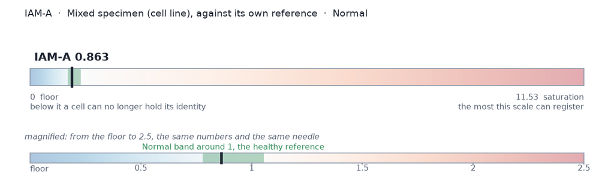

This score is preliminary until IAM-A is officially commissioned on mixed specimen (cell line). **Normal** (Normal 0.779 to 1.055). Held error 0.037452 against 0.043382 predicted by this sample's own loose share (0.09). No outside reference is used: the sample is read against itself.

Counting: 2,346,185 held-error chances counted; from counting alone A lies within 0.858 to 0.869 (95 %), 4 % of the Normal band's width.

## The sample on the globe, against its healthy reference

Open the globe on its own full page (the same layers, larger, on a dark background).

[interactive chart not shown]

## The readings, in plain words

Each gauge runs from 0, the floor (below it a cell can no longer hold its identity), through 1, healthy, to saturation, the most the scale can register. Healthy cells sit in the green band around 1. Moving right means the marks are being lost.

### Which cells are in the sample

Naive b cells 56 %, Lung interstitial macrophages 36 %, T effector memory cd4 4 %, Fallopien tubes epithelium 2 %, read against the 79-cell IAM-Atlas v2.1.

### IAM-A

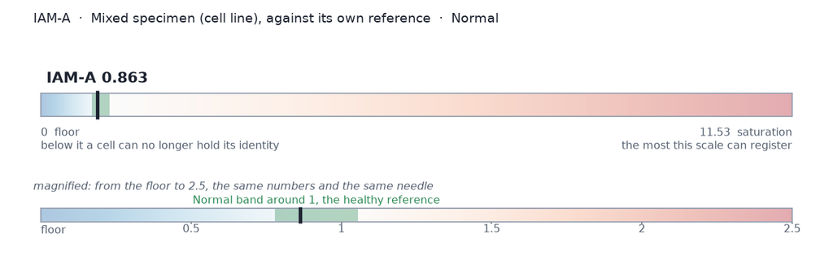

Whether each mark is still held, read against this sample's own reference: no other person is needed.

## Technical record

**chain v4: Met-A on isolated neutrophils (EPIC v1) COMMISSIONED 2026-10-09; Met-A C-score on whole blood (EPIC v1) COMMISSIONED 2026-10-15; IAM-Deconvolver shares (neutrophils, monocytes, CD4 T, CD8 T; arrays) and IAM-A (healthy CD8 T cells, whole-genome bisulfite) COMMISSIONED 2026-10-17; a reading outside these scopes is printed as preliminary until its instrument is commissioned there**. Not a diagnostic test.

# Cellular Performance Gauge - ROUTE

## Stage 0 intake

verdict: **not run** | call rate: - | flags:

## Stage 8 same-run tare

Tare method: step 1 self-tare II (not run), then step 2 median tare: not run

## Stage 6 Met-A C-score

DEVELOPMENT - not commissioned for this specimen

## Stage 7 IAM-A - mixed specimen (cell line)

**IAM-A 0.8633**

**How to read this gauge**

**A misreading to avoid.** It was made more than three times while this gauge was being built, so it is printed on every report: the gauge reads writing on the surface, not holding energy; left is less writing, right is more. The floor is NOT the most a cell can hold, and cancer does NOT lose its identity. Below the floor the bit rate is too low to maintain the cell; cancer moves right, toward the full surface.

## Red flags

| level | code | what |
| --- | --- | --- |
| NOTE | DEVELOPMENT_BUILD | chain v4: Met-A on isolated neutrophils (EPIC v1) COMMISSIONED 2026-10-09; Met-A C-score on whole blood (EPIC v1) COMMISSIONED 2026-10-15; IAM-Deconvolver shares (neutrophils, monocytes, CD4 T, CD8 T;… |

## Why the chain stopped or flagged this sample

[output not shown]

## Safeguards

[output not shown]

## Troubleshooting

| condition | what to do |
| --- | --- |
| none | no condition on this specimen needs operator action |

## Integrity

| item | sha256 / version |
| --- | --- |
| Grn IDAT | intake not run |
| Red IDAT | intake not run |
| chain commit | 3ab30ad9 (uncommitted changes) |
| methylprep | not importable |
| python | 3.11.16 |

## Chain file inventory

[output not shown]

## Run it yourself

From `Biological_Physics/MethylPhys/chain/MethylPhys_Interface` at the chain commit above:

```
python run_sample.py --pat /Users/hmahaffeyges/.claude-science/orgs/b3fa12f1-8d79-429e-bb1a-aa5513757937/workspaces/1ee15a11-4119-40d8-abd8-f57c96e7c721/p1pat/GSM4914802/eout/GSM4914802.pat.gz --specimen "cell line" --id ROUTE --dev-seq-values 1
```

The frozen inputs are listed in the inventory with their hashes; a reading made from the same IDATs, commit and inputs is identical.

## The chain (SOP v3 section 2b)

| # | stage | status on this build |
| --- | --- | --- |
| 0 | Intake | running (specimen rule; sex and age optional; identifiers hashed in bundle and ledger) |
| 1 | Calibration | running |
| 2 | Composition, blood groups | running |
| 3 | Atlas deconvolution | development flag --dev-atlas-e; IAM-Atlas v2.1 COMMISSIONED 2026-10-16 for three cell references (cortical neurons, lung bronchus epithelium, naive CD4 T cells; 450K) and the colon and lung blind site… |
| 4 | NILC component separation | development flag --dev-nilc |
| 5 | Met-A | running (neutrophils); B cells behind --dev-percell-b |
| 6 | C-score | COMMISSIONED 2026-10-15 on whole blood (one-sided band, upper 1.152); IAM-A C-score in Stage Q (development) |
| 7 | IAM-A | COMMISSIONED 2026-10-17 on healthy blood CD8 T cells (whole-genome bisulfite), read against its own reference; other specimens development |
| G | Group-A | COMMISSIONED 2026-10-20 for groups of whole bloods run in one series (chain/stage_groupa.py): compares groups, not one person |
| 8 | Same-run tare | running (self-tare II, then the median tare; self-tare II wired 2026-10-04) |
| 9 | Noise gate | running (state withheld above N_max untared, and below 90 % noise-site coverage) |
| 10 | Directional decomposition | development flag --dev-direction |
| 11 | Sky map | development flag --dev-sky |
| 12 | Sky statistics | development flag --dev-sky |
| 13 | Report | running |
| 3b | Trace-cell detection | development flag --dev-trace |
| 3c | Foreign-cell detection | development flag --dev-foreign |
| 11b | Surface brightness | development flag --dev-brightness |
| 12b | Difference map | running with --prior-betas (per-address difference; the sky drawing is not built) |

## Toolkit stages

| stage | name | module | status | note |
| --- | --- | --- | --- | --- |
| 3 | Atlas deconvolution (atlas_e, --dev-atlas-e) | chain/dev_stages.py | NOT_RUN | behind a development flag (not given), or not run on this specimen |
| 3b | Trace-cell detection (--dev-trace) | chain/dev_stages.py | NOT_RUN | behind a development flag (not given), or not run on this specimen |
| 3c | Foreign-cell detection (--dev-foreign) | chain/dev_stages.py | NOT_RUN | behind a development flag (not given), or not run on this specimen |
| 4 | NILC component separation (NILC-e, --dev-nilc) | chain/dev_stages.py | NOT_RUN | behind a development flag (not given), or not run on this specimen |
| 10 | Directional decomposition (--dev-direction) | chain/dev_stages.py | NOT_RUN | behind a development flag (not given), or not run on this specimen |
| 11 | Sky map (--dev-sky) | chain/dev_stages.py | NOT_RUN | behind a development flag (not given), or not run on this specimen |
| 11b | Surface brightness (--dev-brightness) | chain/dev_stages.py | NOT_RUN | behind a development flag (not given), or not run on this specimen |
| 12 | Sky statistics (--dev-sky) | chain/sky_statistics.py | NOT_RUN | behind a development flag (not given), or not run on this specimen |
| 12b | Difference map | chain/serial_mode.py | NOT_RUN | built; not run on this specimen |
| 12 | apodised mask | - | NOT_BUILT | listed under stage 12 as a tool to build |
| 12 | beam smoothing | - | NOT_BUILT | listed under stage 12 as a tool to build |
| 12 | cell-type covariance in the separation (GLS) | - | NOT_BUILT | listed under stage 12 as a tool to build |
| 12 | Fisher degeneracy of the composition | - | NOT_BUILT | listed under stage 12 as a tool to build |
| 12 | ILC on the residual sky | - | NOT_BUILT | listed under stage 12 as a tool to build |
| 12 | per-specimen composition posterior | - | NOT_BUILT | listed under stage 12 as a tool to build |
| 12 | cross-spectra between cell panels | - | NOT_BUILT | listed under stage 12 as a tool to build |
| 12 | difference map drawn as a sky | - | NOT_BUILT | listed under stage 12 as a tool to build |

**bundle (JSON, also written beside this page)**

[output not shown]

[output not shown]